# 20230505作业

Lin,Xiaohe

2023-05-11

## 载入依赖包

```r
library(MASS)
library(relaimpo)
library(car)
```

## 数据读取与转化

```r
acute_data <- read.csv('Ceriodaphnia_dubia_acute_data.csv',header = T)
acute_data$ln_DOC <- log(acute_data$DOC)
acute_data$ln_Hardness <- log(acute_data$Hardness)
acute_data$ln_Observed_Acute_EC50s <- log(acute_data$Observed_Acute_EC50s)
N <- log(length(acute_data$Species))
```

## 无交互作用模型的建立与比较

```r
mod.1 <- lm(ln_Observed_Acute_EC50s~ln_DOC+ln_Hardness+pH,data = acute_data)
AIC_mod <- stepAIC(mod.1,direction = c('both'),k = 2)
```

```
## Start:  AIC=-71.76
## ln_Observed_Acute_EC50s ~ ln_DOC + ln_Hardness + pH
##
##               Df Sum of Sq    RSS     AIC
## - ln_Hardness  1     0.005 34.789 -73.745
## <none>                     34.784 -71.758
## - pH           1    17.130 51.914 -38.920
## - ln_DOC       1    43.351 78.134  -3.351
##
## Step:  AIC=-73.75
## ln_Observed_Acute_EC50s ~ ln_DOC + pH
##
##               Df Sum of Sq    RSS     AIC
## <none>                     34.789 -73.745
## + ln_Hardness  1     0.005 34.784 -71.758
## - pH           1    19.203 53.992 -37.506
## - ln_DOC       1    43.462 78.251  -5.221
```

```r
BIC_mod <- stepAIC(mod.1,direction = c('both'),k = N)
```

```
## Start:  AIC=-61.89
## ln_Observed_Acute_EC50s ~ ln_DOC + ln_Hardness + pH
##
##               Df Sum of Sq    RSS     AIC
## - ln_Hardness  1     0.005 34.789 -66.347
## <none>                     34.784 -61.894
## - pH           1    17.130 51.914 -31.522
## - ln_DOC       1    43.351 78.134   4.047
##
## Step:  AIC=-66.35
## ln_Observed_Acute_EC50s ~ ln_DOC + pH
##
##               Df Sum of Sq    RSS     AIC
## <none>                     34.789 -66.347
## + ln_Hardness  1     0.005 34.784 -61.894
## - pH           1    19.203 53.992 -32.574
## - ln_DOC       1    43.462 78.251  -0.289
```

```r
# 我们发现去除ln_Hardness项后AIC和BIC值更小
# 因此选择模型 ln_Observed_Acute_EC50s ~ ln_DOC + pH
mod.1 <- lm(ln_Observed_Acute_EC50s~ln_DOC+pH,data = acute_data)
summary(mod.1)
```

```
##
## Call:
## lm(formula = ln_Observed_Acute_EC50s ~ ln_DOC + pH, data = acute_data)
##
## Residuals:
##      Min       1Q   Median       3Q      Max
## -1.45477 -0.28503  0.04482  0.40383  2.09872
##
## Coefficients:
##             Estimate Std. Error t value Pr(>|t|)
## (Intercept) -3.84786    1.00112  -3.844 0.000235 ***
## ln_DOC       0.62507    0.06102  10.244  < 2e-16 ***
## pH           0.86985    0.12775   6.809 1.37e-09 ***
## ---
## Signif. codes:  0 '***' 0.001 '**' 0.01 '*' 0.05 '.' 0.1 ' ' 1
##
## Residual standard error: 0.6435 on 84 degrees of freedom
## Multiple R-squared:  0.6365, Adjusted R-squared:  0.6278
## F-statistic: 73.53 on 2 and 84 DF,  p-value: < 2.2e-16
```

结果解读：

- log(DOC)对急性EC50有显著影响，若控制pH不变，log(DOC)每升高1mg/L，log(EC50)增加0.62507
- pH对急性EC50有显著影响，若控制DOC不变，pH每升高1，log(EC50)增加0.86985
- 截距为-3.85，含义是当log(DOC)和pH等于0时，log(EC50)为-3.84786
- R-squared等于0.6365，表明log(DOC)和pH一起可以解释63.65%的log(EC50)变异

```r
# 我们进一步分析各解释变量的相对贡献
calc.relimp(mod.1)
```

```
## Response variable: ln_Observed_Acute_EC50s
## Total response variance: 1.112723
## Analysis based on 87 observations
##
## 2 Regressors:
## ln_DOC pH
## Proportion of variance explained by model: 63.65%
## Metrics are not normalized (rela=FALSE).
##
## Relative importance metrics:
##
##              lmg
## ln_DOC 0.4449832
## pH     0.1914742
##
## Average coefficients for different model sizes:
##
##               1X       2Xs
## ln_DOC 0.6119861 0.6250749
## pH     0.8286280 0.8698530
```

结果解读：

- log(DOC)和pH一起可以解释63.65%的log(EC50)变异
- 其中，log(DOC)贡献了其中的44.50%，pH贡献了其中的19.150%

## 无交互作用模型的诊断

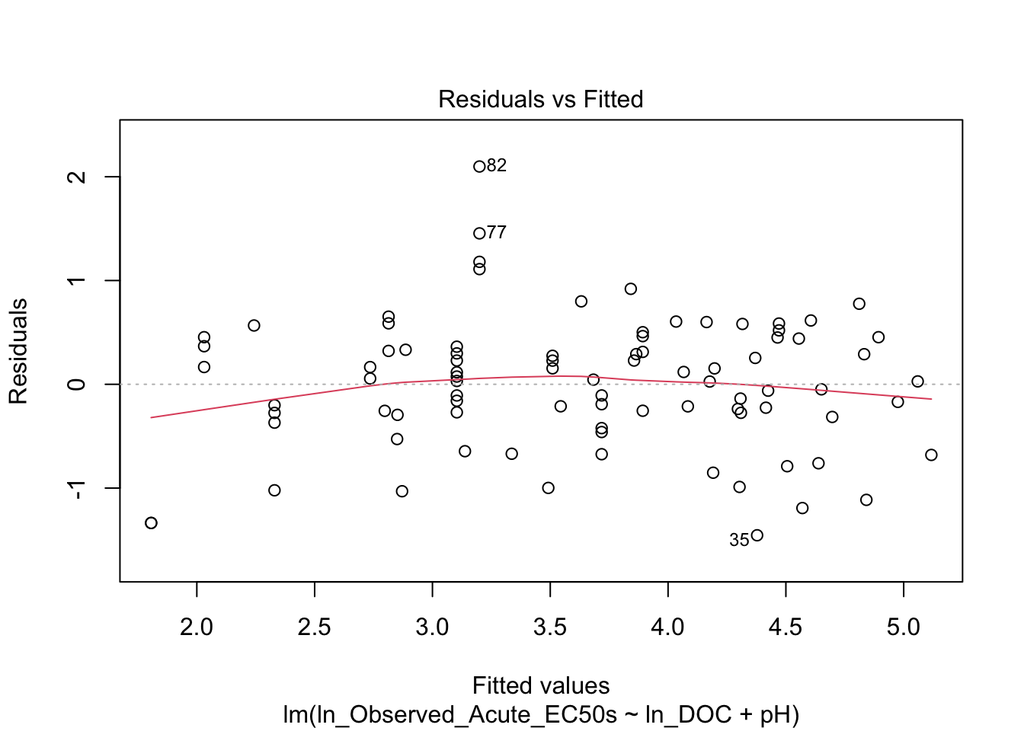

```r
# 残差略有非线性，识别出异常点35,77和82
plot(mod.1, which=1)
```

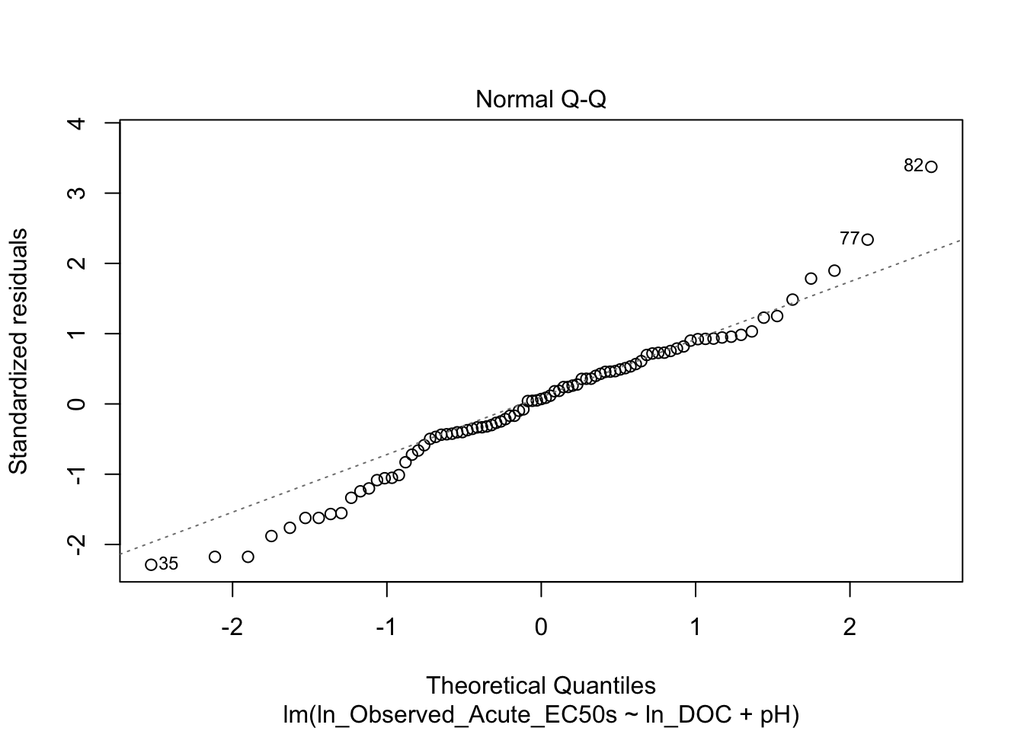

```r
# 图上残差大多落在对角线上，比较符合正态分布，识别出异常点35,77和82
plot(mod.1, which=2)
```

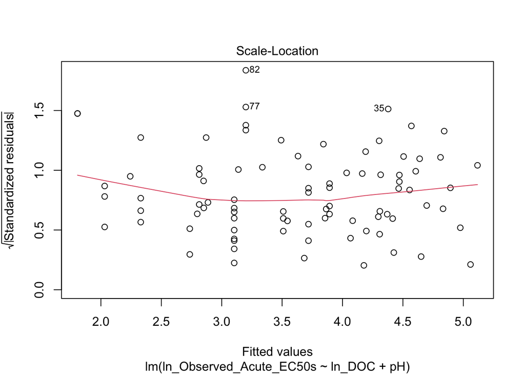

```r
# 模型的残差存在异方差性，识别出异常点35,77和82
plot(mod.1, which=3)
```

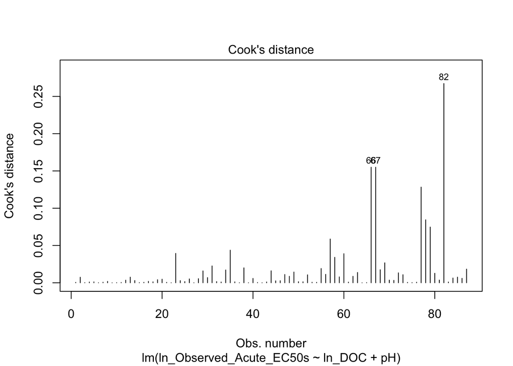

```r
# 图上显示cook's distance均小于1，说明无高影响点
plot(mod.1, which=4)
```